# Solução Lista 4

Cristiano de Carvalho Santos

1. A potenciação é uma das operações básicas dos números naturais, onde um dado número $x$ denominado base, é multiplicado n vezes, n sendo denominado expoente, resultando na potência $b$, ou seja, $x^n = b$. Dessa forma, crie três funções, usando os comandos de repetição for(), while() e repeat(), para calcular a potência de um número. Você deve passar como parâmetros das funções a base $x$ e o expoente $n$ e as funções devem retornar a potência $b$. Utilize a função microbenchmark() do pacote ‘microbenchmark’ para comparar os tempos computacionais de suas funções.

```r
#Usando a função for():
potencia_for <- function(base, expoente){

  resultado <- 1 #devo inciar com 1 para começar o loop
  for (i in 1:expoente){
    resultado <- resultado*base
  }
  return(resultado)
}

#Usando a função while():
potencia_while <- function(base, expoente){

  resultado <- 1
  i <- 1
  while (i <= expoente) {
    resultado = resultado*base
    i <- i+1
  }
  return(resultado)
}

#Usando a função repeat():
potencia_repeat <- function(base, expoente){

  resultado <- 1
  i <- 1
  repeat{
    resultado = resultado*base
    if(i == (expoente)) break
    i = i+1
  }
  return(resultado)
}

#Vetor de dados:
base = 2
expoente = 3

#Conferindo se os reusltados são iguais:
all.equal(potencia_for(base, expoente), potencia_while(base, expoente), potencia_repeat(base, expoente))
```

```
## [1] TRUE
```

```r
#Comparando os tempos:
microbenchmark(potencia_for(base, expoente), potencia_while(base, expoente), potencia_repeat(base, expoente))
```

```
## Unit: nanoseconds
##                             expr min  lq mean median  uq   max neval cld
##     potencia_for(base, expoente) 600 600  735    700 700  4700   100   a
##   potencia_while(base, expoente) 600 700  929    700 800 19900   100   a
##  potencia_repeat(base, expoente) 600 700  731    700 700  2900   100   a
```

2. Sendo $H = 1/2 + 2/3 + 3/4 + ... + N/(N + 1)$, faça duas funções, uma usando alguma estrutura de repetido aprendida em sala de aula (for(), while() ou repeat()) e outra usando a função seq(), que retorne o valor de H ao passar para a função os valores de N.

```r
#Usando a função for():
soma_serie_for <- function(N){
  H <- 0
  for (i in 1:N){
    H <- (i/(i + 1)) + H
  }
  return(H)
}

#Usando a função while():
soma_serie_while <- function(N){

  H <- 0
  i <- 1
  while (i <= N) {
    H <- (i/(i + 1)) + H
    i <- i+1
  }
  return(H)
}

#Usando a função repeat():
soma_serie_repeat <- function(N){

  H <- 0
  i <- 1
  repeat{
    H <- (i/(i + 1)) + H
    if(i == N) break
    i = i+1
  }
  return(H)
}

#Utilizando a função seq():
soma_serie_seq <- function(N){
  H <- sum(seq(1,N)/seq(2,N + 1))
  return(H)
}

N <- 4

soma_serie_for(N)
```

```
## [1] 2.716667
```

```r
soma_serie_while(N)
```

```
## [1] 2.716667
```

```r
soma_serie_repeat(N)
```

```
## [1] 2.716667
```

```r
soma_serie_seq(N)
```

```
## [1] 2.716667
```

3. Crie uma função que gere 1000 amostras da distribuição normal, cada uma com tamanho amostral igual a n=100 e parâmetros da média e desvio padrão escolhidos por você. Para cada amostra gerada, faça o cálculo de LI e LS descritos abaixo e calcule a proporção de amostras em que $LI \leq \mu \leq LS$ seja verdadeiro:

   $$LI = \overline{x} - z_{\alpha/2}\frac{\sigma}{\sqrt{n}}$$
   $$LS = \overline{x} + z_{\alpha/2}\frac{\sigma}{\sqrt{n}}$$

O valor de $z_{\alpha/2}$ pode ser gerado o R utilizando o comando -qnorm(0.025,0,1), considerando que o valor de $\alpha$ seja 0.05.

```r
#Primeiramente, resolvendo com for():
intervalo_for <- function(n,media, variancia){
  ic <- vector()
  for(i in 1:1000){
    dados <- rnorm(n,media,sqrt(variancia))
    LI <- mean(dados) - (qnorm(0.975,0,1))*sqrt(variancia)/sqrt(n)
    LS <- mean(dados) + (qnorm(0.975,0,1))*sqrt(variancia)/sqrt(n)

    ic[i] <- ifelse(media >= LI & media <= LS,1,0)
  }
  proporcao <- sum(ic)/1000
  return(proporcao)
}

 set.seed(12345)
intervalo_for(100,1,2) #Por exemplo, normal com média 1 e variancia 2
```

```
## [1] 0.945
```

```r
# Resolvendo com while():
intervalo_while <- function(n,media, variancia){
  ic <- vector()
  i <- 1
  while(i <= 1000){
    dados <- rnorm(n,media,sqrt(variancia))
    LI <- mean(dados) - (qnorm(0.975,0,1))*sqrt(variancia)/sqrt(n)
    LS <- mean(dados) + (qnorm(0.975,0,1))*sqrt(variancia)/sqrt(n)

    ic[i] <- ifelse(media >= LI & media <= LS,1,0)

    i <- i+1
  }
  proporcao <- sum(ic)/1000
  return(proporcao)
}

 set.seed(12345)
intervalo_while(100,1,2)
```

```
## [1] 0.945
```

```r
#Resolvendo com repeat():
intervalo_repeat <- function(n,media, variancia){
  ic <- vector()
  i <- 1
  repeat{

    dados <- rnorm(n,media,sqrt(variancia))
    LI <- mean(dados) - (qnorm(0.975,0,1))*sqrt(variancia)/sqrt(n)
    LS <- mean(dados) + (qnorm(0.975,0,1))*sqrt(variancia)/sqrt(n)

    ic[i] <- ifelse(media >= LI & media <= LS,1,0)
    i <- i+1
    if(i > 1000) break


  }
  proporcao <- sum(ic)/1000
  return(proporcao)
}

 set.seed(12345)
intervalo_repeat(100,1,2)
```

```
## [1] 0.945
```

4. Descubra o fazem as funções split e aggregate. Crie um exemplo utilizando o banco de dados data(esoph) para ilustrar o uso dessas funções. Utilize help(esoph) para saber mais sobre os dados.

A função aggregate() divide os dados em subconjuntos, calcula estatísticas de resumo para cada subconjunto criado e retorna o resultado

```r
data(esoph)
help(esoph)
```

```
## starting httpd help server ... done
```

```r
head(esoph)
```

```
##   agegp     alcgp    tobgp ncases ncontrols
## 1 25-34 0-39g/day 0-9g/day      0        40
## 2 25-34 0-39g/day    10-19      0        10
## 3 25-34 0-39g/day    20-29      0         6
## 4 25-34 0-39g/day      30+      0         5
## 5 25-34     40-79 0-9g/day      0        27
## 6 25-34     40-79    10-19      0         7
```

```r
#Utilizando o banco de dados, calculei a média para cada grupo da variavel 'tobgp'.
aggregate(. ~ tobgp, data = esoph, mean) #
```

```
##      tobgp agegp alcgp   ncases ncontrols
## 1 0-9g/day  3.50  2.50 3.250000 21.875000
## 2    10-19  3.50  2.50 2.416667  9.833333
## 3    20-29  3.25  2.45 1.650000  6.600000
## 4      30+  3.25  2.35 1.550000  4.100000
```

Para a função, split(x, f), divide os dados no vector X em grupos definidos por f. A função with() serve para saber que tobgp é uma covariavel do esopph.

```r
esoph_novo = with(esoph, split(esoph[,-3], tobgp))
names(esoph_novo)
```

```
## [1] "0-9g/day" "10-19"    "20-29"    "30+"
```

```r
esoph_novo$`10-19` #exemplo
```

```
##    agegp     alcgp ncases ncontrols
## 2  25-34 0-39g/day      0        10
## 6  25-34     40-79      0         7
## 10 25-34    80-119      0         1
## 13 25-34      120+      1         1
## 17 35-44 0-39g/day      1        14
## 21 35-44     40-79      3        23
## 25 35-44    80-119      0         6
## 29 35-44      120+      0         3
## 32 45-54 0-39g/day      0        18
## 36 45-54     40-79      4        21
## 40 45-54    80-119      6        14
## 44 45-54      120+      3         4
## 48 55-64 0-39g/day      3        22
## 52 55-64     40-79      6        21
## 56 55-64    80-119      8        15
## 60 55-64      120+      6         7
## 64 65-74 0-39g/day      4        14
## 68 65-74     40-79      3        10
## 71 65-74    80-119      4        12
## 75 65-74      120+      1         2
## 79   75+ 0-39g/day      2         6
## 82   75+     40-79      1         3
## 86   75+    80-119      1         1
## 88   75+      120+      1         1
```

5. Construa duas funções, uma usando if e else e outra usando switch, que calcule, a partir de um vetor de dados, a média, a variância e construa um boxplot. A função deve ter como parâmetros o vetor de dados e a medida escolhida.

```r
dados = rexp(100) #gerando os dados de uma exponencial com media 1

#Usando if else:
calculo_ifelse <- function(dados, tipo) {
  medida = NULL
  if (tipo == "Media"){
    medida = mean(dados)
  }else if(tipo == "Variancia"){
    medida = var(dados)
  }else if(tipo == "Boxplot"){
    boxplot(dados)
  }
  return(medida)

}

calculo_ifelse(dados,"Variancia") #exemplo
```

```
## [1] 1.096514
```

```r
#Usando if else:
calculo_switch <- function(dados, tipo){

  switch(tipo,
         Media = mean(dados),
         Variancia = var(dados),
         Boxplot = boxplot(dados),
  )
}

calculo_switch(dados,"Variancia")
```

```
## [1] 1.096514
```

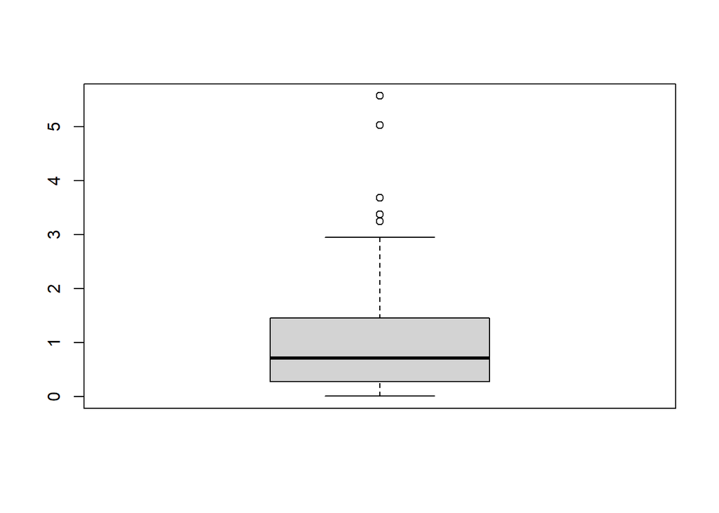

```r
calculo_switch(dados,"Boxplot")
```

6. Gere um vetor de 100 observações da distribuição exponencial com média 1 e categorize os dados em três categorias: 0 para observações menores que 0.5, 1 para valores entre 0.5 e 1, 2 para valores maiores que 1. Construa três funções para fazer a categorização, o primeiro usando if e else, segundo usando o ifelse e o terceiro usando a função cut().

```r
#Usando if else:
dados = rexp(100)
cat1 = dados
for(i in 1:length(dados)){

  if(dados[i]< 0.5){
    cat1[i] = 0
  }
  else if(dados[i]<1){
    cat1[i] = 1
  }else{
    cat1[i] = 2
  }
}

#Usando ifelse:
cat2  = ifelse(dados< 0.5,0,ifelse(dados<1,1,2))

#Usando cut():
cat3 = cut(dados, c(0,0.5,1,Inf),labels = c(0,1,2))


data.frame(dados,cat1, cat2, cat3) #conferindo
```

```
##          dados cat1 cat2 cat3
## 1   0.83221502    1    1    1
## 2   0.31817091    0    0    0
## 3   0.34832858    0    0    0
## 4   0.83025198    1    1    1
## 5   0.41395947    0    0    0
## 6   2.12923557    2    2    2
## 7   0.74861573    1    1    1
## 8   1.18755125    2    2    2
## 9   1.52679913    2    2    2
## 10  0.14715819    0    0    0
## 11  0.20560866    0    0    0
## 12  0.37234518    0    0    0
## 13  0.10768823    0    0    0
## 14  1.34568078    2    2    2
```

[output cut: 86 more lines]